# Particle Interactions Puzzle

**By Duncan McGough**

This appears to be the Vicsek model.

```python
import particle_interactions_puzzle as pi
```

## Problem 1: Small Noise

Let's set up our problem with the following parameters, using $\eta = 0.01$:

```python
N = 125
L = 5
R = 1
v = 1
dt = 0.25

eta = 0.01

sim = pi.Simulation(N,L,eta,v,dt,R)
sim
```

```
=================== Simulation ===================
Current time: 0
Particles: 125
Domain size: 5
Timestep: 0.25
Noise: 0.01
Particle speed: 1
```

Visualizing the initial flow field:

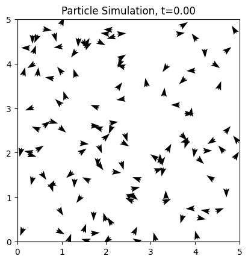

```python
pi.plot_simulation_timestep(sim)
```

And running out the simulation for a while, we can see that with small noise that there exists "flocking" behavior in the particle swarm:

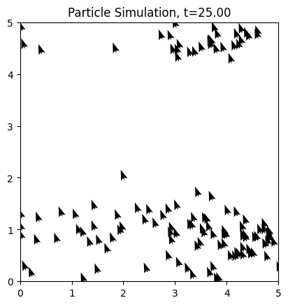

```python
for _ in range(100):
    sim = sim.to_timestepped()
pi.plot_simulation_timestep(sim)
```

## Problem 1: Large Noise

Now, let's set up the same problem now with a larger noise parameter $\eta = 0.99$:

```python
eta = 0.99

sim = pi.Simulation(N,L,eta,v,dt,R)
sim
```

```
=================== Simulation ===================
Current time: 0
Particles: 125
Domain size: 5
Timestep: 0.25
Noise: 0.99
Particle speed: 1
```

Visualizing again the initial flowfield:

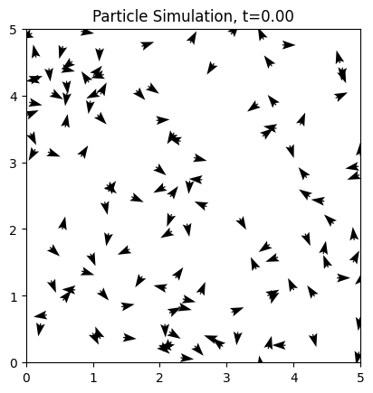

```python
pi.plot_simulation_timestep(sim)
```

And running out the simulation for a while, we can see that with large noise the flocking is no longer seen, with consistent more random motion:

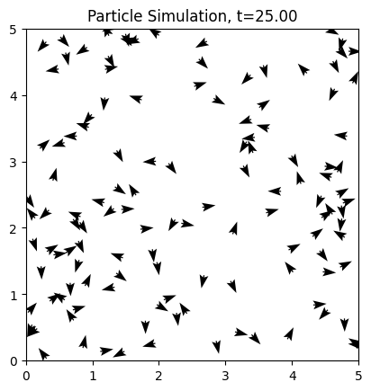

```python
for _ in range(100):
    sim = sim.to_timestepped()
pi.plot_simulation_timestep(sim)
```

## Problem 2: Polarization and Order Parameters

Plotting the stationary order parameter, we can clearly see the sharp transition when the particle swarm swaps between ordered flow and unordered flow, sweeping on noise:

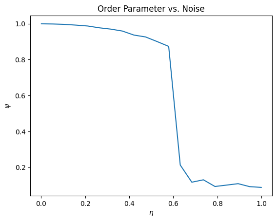

```python
pi.plot_stationary_order_parameter(N,L,R,v,dt)
```

# Problem 3

Now, considering $\eta$ such that a critical $\eta_c$ exists where phase transition occurs, we can leverage minimizers to iteratively drive a residual to zero where $\eta_c = 0.5$:

```python
nc = 0.5
R_opt, v_opt = pi.optimize_for_critical_noise(N, L, dt, nc)
```

Plotting this using the optimized values, we can see it indeed lands on $\eta_c = 0.5$:

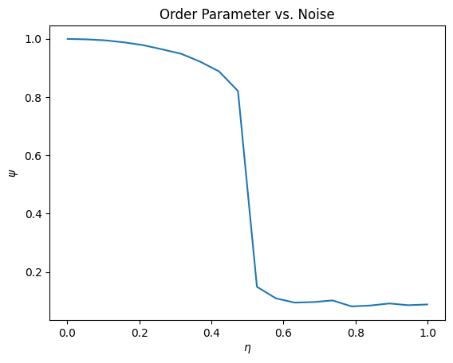

```python
pi.plot_stationary_order_parameter(N,L,R_opt,v_opt,dt)
```